# 클린업 1주차 패키지

Donghwan Kim

2023-09-10

# Chapter 1 : Data Preprocessing

```r
getwd()
train_data = read.csv("train.csv")
test_data = read.csv("test.csv")
```

## 문제1

```r
# 대강 살펴보기
train_data %>% head(3)
```

```
##   X id X.checking_status. X.duration.              X.credit_history. X.purpose.
## 1 1  1                 <0           6 critical/other existing credit   radio/tv
## 2 2  2           0<=X<200          48                  existing paid   radio/tv
## 3 3  3        no checking          12 critical/other existing credit  education
##   X.credit_amount. X.savings_status. X.employment. X.installment_commitment.
## 1             1169  no known savings           >=7                         4
## 2             5951              <100        1<=X<4                         2
## 3             2096              <100        4<=X<7                         2
##   X.personal_status. X.other_parties. X.residence_since. X.property_magnitude.
## 1        male single             none                  4           real estate
## 2 female div/dep/mar             none                  2           real estate
## 3        male single             none                  3           real estate
##   X.age. X.other_payment_plans. X.housing. X.existing_credits.
## 1     67                   none        own                   2
## 2     22                   none        own                   1
## 3     49                   none        own                   1
##               X.job. X.num_dependents. X.own_telephone. X.foreign_worker.
## 1            skilled                 1              yes               yes
## 2            skilled                 1             none               yes
## 3 unskilled resident                 2             none               yes
##   X.class.
## 1     good
## 2      bad
## 3     good
```

```r
# 차원확인하기
train_data %>% dim()
```

```
## [1] 800  23
```

```r
# 자료 타입 확인하기
# x변수가 정수형과 범주형으로 구성되어있음.
train_data %>% str()
```

```
## 'data.frame':    800 obs. of  23 variables:
##  $ X                        : int  1 2 3 4 5 6 7 8 9 10 ...
##  $ id                       : int  1 2 3 4 5 6 7 8 9 10 ...
##  $ X.checking_status.       : chr  "<0" "0<=X<200" "no checking" "<0" ...
##  $ X.duration.              : int  6 48 12 42 24 36 24 36 12 30 ...
##  $ X.credit_history.        : chr  "critical/other existing credit" "existing paid" "critical/other existing credit" "existing paid" ...
##  $ X.purpose.               : chr  "radio/tv" "radio/tv" "education" "furniture/equipment" ...
##  $ X.credit_amount.         : int  1169 5951 2096 7882 4870 9055 2835 6948 3059 5234 ...
##  $ X.savings_status.        : chr  "no known savings" "<100" "<100" "<100" ...
##  $ X.employment.            : chr  ">=7" "1<=X<4" "4<=X<7" "4<=X<7" ...
##  $ X.installment_commitment.: int  4 2 2 2 3 2 3 2 2 4 ...
##  $ X.personal_status.       : chr  "male single" "female div/dep/mar" "male single" "male single" ...
##  $ X.other_parties.         : chr  "none" "none" "none" "guarantor" ...
##  $ X.residence_since.       : int  4 2 3 4 4 4 4 2 4 2 ...
##  $ X.property_magnitude.    : chr  "real estate" "real estate" "real estate" "life insurance" ...
##  $ X.age.                   : int  67 22 49 45 53 35 53 35 61 28 ...
##  $ X.other_payment_plans.   : chr  "none" "none" "none" "none" ...
##  $ X.housing.               : chr  "own" "own" "own" "for free" ...
##  $ X.existing_credits.      : int  2 1 1 1 2 1 1 1 1 2 ...
##  $ X.job.                   : chr  "skilled" "skilled" "unskilled resident" "skilled" ...
##  $ X.num_dependents.        : int  1 1 2 2 2 2 1 1 1 1 ...
##  $ X.own_telephone.         : chr  "yes" "none" "none" "none" ...
##  $ X.foreign_worker.        : chr  "yes" "yes" "yes" "yes" ...
##  $ X.class.                 : chr  "good" "bad" "good" "good" ...
```

```r
# 기초통계량 확인하기
train_data %>% describe()
```

```
## .
##
##  23  Variables      800  Observations
## --------------------------------------------------------------------------------
## X
##        n  missing distinct     Info     Mean      Gmd      .05      .10
##      800        0      800        1    400.5      267    40.95    80.90
##      .25      .50      .75      .90      .95
##   200.75   400.50   600.25   720.10   760.05
##
## lowest :   1   2   3   4   5, highest: 796 797 798 799 800
## --------------------------------------------------------------------------------
## id
##        n  missing distinct     Info     Mean      Gmd      .05      .10
##      800        0      800        1    400.5      267    40.95    80.90
##      .25      .50      .75      .90      .95
##   200.75   400.50   600.25   720.10   760.05
##
## lowest :   1   2   3   4   5, highest: 796 797 798 799 800
## --------------------------------------------------------------------------------
## X.checking_status.
##        n  missing distinct
##      800        0        4
##
## Value               <0       >=200    0<=X<200 no checking
## Frequency          209          55         226         310
## Proportion       0.261       0.069       0.282       0.388
## --------------------------------------------------------------------------------
## X.duration.
##        n  missing distinct     Info     Mean      Gmd      .05      .10
##      800        0       33    0.984    20.65    13.01      6.0      8.9
##      .25      .50      .75      .90      .95
##     12.0     18.0     24.0     36.0     48.0
##
## lowest :  4  5  6  7  8, highest: 47 48 54 60 72
## --------------------------------------------------------------------------------
## X.credit_history.
##        n  missing distinct
##      800        0        5
##
```

[output cut: 156 more lines]

```
##        n  missing distinct
##      800        0        2
##
## Value         no   yes
## Frequency     27   773
## Proportion 0.034 0.966
## --------------------------------------------------------------------------------
## X.class.
##        n  missing distinct
##      800        0        2
##
## Value        bad  good
## Frequency    239   561
## Proportion 0.299 0.701
## --------------------------------------------------------------------------------
```

```r
# 결측치 확인 결과 없음.
train_data %>% is.na() %>% sum()
```

```
## [1] 0
```

## 문제2

```r
# 불필요한 열 제거.
train <- train_data %>% select(-c(id,X))
test <- test_data %>% select(-c(id,X))
train %>% colnames() %>% length()
```

```
## [1] 21
```

```r
test %>% colnames() %>% length()
```

```
## [1] 21
```

## 문제3

```r
# 열 이름 바꾸기.
for (i in 1:21){
  names(train)[[i]] <- strsplit(names(train)[[i]],"\\.") %>% map_chr(.,2)
  names(test)[[i]] <- strsplit(names(test)[[i]],"\\.") %>% map_chr(.,2)
}
names(train)
```

```
##  [1] "checking_status"        "duration"               "credit_history"
##  [4] "purpose"                "credit_amount"          "savings_status"
##  [7] "employment"             "installment_commitment" "personal_status"
## [10] "other_parties"          "residence_since"        "property_magnitude"
## [13] "age"                    "other_payment_plans"    "housing"
## [16] "existing_credits"       "job"                    "num_dependents"
## [19] "own_telephone"          "foreign_worker"         "class"
```

```r
names(test)
```

```
##  [1] "checking_status"        "duration"               "credit_history"
##  [4] "purpose"                "credit_amount"          "savings_status"
##  [7] "employment"             "installment_commitment" "personal_status"
## [10] "other_parties"          "residence_since"        "property_magnitude"
## [13] "age"                    "other_payment_plans"    "housing"
## [16] "existing_credits"       "job"                    "num_dependents"
## [19] "own_telephone"          "foreign_worker"         "class"
```

## 문제4

```r
# personal_status 열로 파생변수 만들기.
train <- train %>%
  mutate(sex = strsplit(personal_status," ") %>% map_chr(.,1),
         marital_status = strsplit(personal_status," ") %>% map_chr(.,2)
         ) %>%
  select(-(personal_status))

test <- test %>%
  mutate(sex = strsplit(personal_status," ") %>% map_chr(.,1),
         marital_status = strsplit(personal_status," ") %>% map_chr(.,2)
         ) %>%
  select(-(personal_status))
```

```
##  [1] "checking_status"        "duration"               "credit_history"
##  [4] "purpose"                "credit_amount"          "savings_status"
##  [7] "employment"             "installment_commitment" "other_parties"
## [10] "residence_since"        "property_magnitude"     "age"
## [13] "other_payment_plans"    "housing"                "existing_credits"
## [16] "job"                    "num_dependents"         "own_telephone"
## [19] "foreign_worker"         "class"                  "sex"
## [22] "marital_status"
```

```
## [1] "--------------------------------------------------------------------"
```

```
##  [1] "checking_status"        "duration"               "credit_history"
##  [4] "purpose"                "credit_amount"          "savings_status"
##  [7] "employment"             "installment_commitment" "other_parties"
## [10] "residence_since"        "property_magnitude"     "age"
## [13] "other_payment_plans"    "housing"                "existing_credits"
## [16] "job"                    "num_dependents"         "own_telephone"
## [19] "foreign_worker"         "class"                  "sex"
## [22] "marital_status"
```

## 문제5

```r
#결측치 변경 전 결측치 갯수 확인
cat('train missing before : ',
      sum(train['checking_status']=='no checking') + sum(train['savings_status']=='no known savings')+sum(train['property_magnitude']=='no known property'),end= "\n")
```

```
## train missing before :  580
```

```r
cat('test missing before : ',
      sum(test['checking_status']=='no checking') + sum(test['savings_status']=='no known savings')+sum(test['property_magnitude']=='no known property'))
```

```
## test missing before :  151
```

```r
# 결측치 변경 후 결측치 갯수 동일
train <- train %>%
  mutate(checking_status = ifelse(checking_status=="no checking",NA,checking_status),
         savings_status = ifelse(savings_status == "no known savings",NA,savings_status),
         property_magnitude = ifelse(property_magnitude == "no known property",NA,property_magnitude))
test <- test %>%
  mutate(checking_status = ifelse(checking_status=="no checking",NA,checking_status),
         savings_status = ifelse(savings_status == "no known savings",NA,savings_status),
         property_magnitude = ifelse(property_magnitude == "no known property",NA,property_magnitude))
train %>% is.na() %>% sum() %>% cat('train missing after : ', ., '\n')
```

```
## train missing after :  580
```

```r
test %>% is.na() %>% sum() %>% cat('train missing after : ', ., '\n')
```

```
## train missing after :  151
```

## 문제 6

### 전처리전 갯수확인

```r
# 전처리전 갯수확인
train %>% filter(marital_status=='div/dep/mar' |
                   marital_status=='div/sep' |
                   marital_status=='mar/wid') %>% dim() %>%
  cat('train marital_status before : ', ., '\n')
```

```
## train marital_status before :  363 22
```

```r
test %>% filter(marital_status=='div/dep/mar' |
                   marital_status=='div/sep' |
                   marital_status=='mar/wid') %>% dim() %>%
  cat('test marital_status before : ', ., '\n')
```

```
## test marital_status before :  89 22
```

```r
train %>% filter(credit_history=="no credits/all paid") %>% dim() %>%
cat('train credit_history before : ', ., '\n')
```

```
## train credit_history before :  33 22
```

```r
test %>% filter(credit_history=="no credits/all paid") %>% dim() %>%
cat('test credit_history before : ', ., '\n')
```

```
## test credit_history before :  7 22
```

```r
train <- train %>%
  mutate(credit_history = ifelse(credit_history=="no credits/all paid","no credits",credit_history),
         marital_status = ifelse( marital_status == "div/sep" |
                                   marital_status == "mar/wid",
                                 "div/dep/mar",marital_status))
test <- test %>%
  mutate(credit_history = ifelse(credit_history=="no credits/all paid","no credits",credit_history),
         marital_status = ifelse( marital_status == "div/sep" |
                                   marital_status == "mar/wid",
                                 "div/dep/mar",marital_status))
```

### 전처리후 갯수확인

```r
# 전처리 후 갯수 확인
train %>% filter(marital_status=='div/dep/mar') %>% dim() %>%
  cat('train marital_status after : ', ., '\n')
```

```
## train marital_status after :  363 22
```

```r
test %>% filter(marital_status=='div/dep/mar') %>% dim() %>%
  cat('test marital_status after : ', ., '\n')
```

```
## test marital_status after :  89 22
```

```r
train %>% filter(credit_history=="no credits") %>% dim() %>%
cat('train credit_history after : ', ., '\n')
```

```
## train credit_history after :  33 22
```

```r
test %>% filter(credit_history=="no credits") %>% dim() %>%
cat('test credit_history after : ', ., '\n')
```

```
## test credit_history after :  7 22
```

## 문제 7

### 처리전 unique 확인

```r
# unique 확인
train %>% select(checking_status) %>% distinct()
```

```
##   checking_status
## 1              <0
## 2        0<=X<200
## 3            <NA>
## 4           >=200
```

```r
train %>% select(savings_status) %>% distinct()
```

```
##   savings_status
## 1           <NA>
## 2           <100
## 3    500<=X<1000
## 4         >=1000
## 5     100<=X<500
```

```r
train %>% select(employment) %>% distinct()
```

```
##   employment
## 1        >=7
## 2     1<=X<4
## 3     4<=X<7
## 4 unemployed
## 5         <1
```

```r
# 순서형 자료로 변환
train <- train %>%
  mutate(
    checking_status = case_when(
      checking_status == "<0"~1,
      checking_status == "0<=X<200"~2,
      checking_status == ">=200"~3,
      )
    )
train <- train %>%
  mutate(
    savings_status = case_when(
      savings_status == "<100"~1,
      savings_status == "100<=X<500"~2,
      savings_status == "500<=X<1000"~3,
      savings_status == ">=1000"~4
      )
    )
train <- train %>%
  mutate(
    employment = case_when(
      employment == "unemployed"~1,
      employment == "<1"~2,
      employment == "1<=X<4"~3,
      employment == "4<=X<7"~4,
      employment == ">=7"~5,
      )
    )
```

```r
# test에도 동일하게 순서형 자료로 변환
test <- test %>%
  mutate(
    checking_status = case_when(
      checking_status == "<0"~1,
      checking_status == "0<=X<200"~2,
      checking_status == ">=200"~3,
      )
    )
test <- test %>%
  mutate(
    savings_status = case_when(
      savings_status == "<100"~1,
      savings_status == "100<=X<500"~2,
      savings_status == "500<=X<1000"~3,
      savings_status == ">=1000"~4
      )
    )
test <- test %>%
  mutate(
    employment = case_when(
      employment == "unemployed"~1,
      employment == "<1"~2,
      employment == "1<=X<4"~3,
      employment == "4<=X<7"~4,
      employment == ">=7"~5,
      )
    )
```

### 처리후 unique 확인

```r
# 처리후 unique 확인
train %>% select(checking_status) %>% distinct()
```

```
##   checking_status
## 1               1
## 2               2
## 3              NA
## 4               3
```

```r
train %>% select(savings_status) %>% distinct()
```

```
##   savings_status
## 1             NA
## 2              1
## 3              3
## 4              4
## 5              2
```

```r
train %>% select(employment) %>% distinct()
```

```
##   employment
## 1          5
## 2          3
## 3          4
## 4          1
## 5          2
```

## 문제 보너스 1

```
순서형 변수는 범주간 높음-낮음, 선호-불호, 긍정-부정 등의 순서 혹은 등급을 나타낸다.
반면에 명목형 변수는 이러한 것을 고려하지 않는 변수이다. 이 때문에 순서형 변수를 명목형 변수로 변환시, 순서형 변수에 있던 순서에 대한 정보가 사라지게 됨으로 정보 손실이 발생한다.
```

## 문제 보너스 2

```
checking_status 열에서 no checking은 확인이 안된 것을, saving_satuts 열에서 no known savings는
저축 상태를 알 수 없는 것을 의미함으로 결측치로 처리하는 것이 맞으나, employment에서 unemployed는
고용이 되었는지 되지않았는지 모르는 것을 의미하는 것이 아니고, '고용이 안되었음' 을 의미함으로 결측치로 처리하기에는 부적합하다.
```

## 문제 8

### 변환 전 데이터 type 확인

```r
## 변환 전 데이터 type확인
str(train)
```

```
## 'data.frame':    800 obs. of  22 variables:
##  $ checking_status       : num  1 2 NA 1 1 NA NA 2 NA 2 ...
##  $ duration              : int  6 48 12 42 24 36 24 36 12 30 ...
##  $ credit_history        : chr  "critical/other existing credit" "existing paid" "critical/other existing credit" "existing paid" ...
##  $ purpose               : chr  "radio/tv" "radio/tv" "education" "furniture/equipment" ...
##  $ credit_amount         : int  1169 5951 2096 7882 4870 9055 2835 6948 3059 5234 ...
##  $ savings_status        : num  NA 1 1 1 1 NA 3 1 4 1 ...
##  $ employment            : num  5 3 4 4 3 3 5 3 4 1 ...
##  $ installment_commitment: int  4 2 2 2 3 2 3 2 2 4 ...
##  $ other_parties         : chr  "none" "none" "none" "guarantor" ...
##  $ residence_since       : int  4 2 3 4 4 4 4 2 4 2 ...
##  $ property_magnitude    : chr  "real estate" "real estate" "real estate" "life insurance" ...
##  $ age                   : int  67 22 49 45 53 35 53 35 61 28 ...
##  $ other_payment_plans   : chr  "none" "none" "none" "none" ...
##  $ housing               : chr  "own" "own" "own" "for free" ...
##  $ existing_credits      : int  2 1 1 1 2 1 1 1 1 2 ...
##  $ job                   : chr  "skilled" "skilled" "unskilled resident" "skilled" ...
##  $ num_dependents        : int  1 1 2 2 2 2 1 1 1 1 ...
##  $ own_telephone         : chr  "yes" "none" "none" "none" ...
##  $ foreign_worker        : chr  "yes" "yes" "yes" "yes" ...
##  $ class                 : chr  "good" "bad" "good" "good" ...
##  $ sex                   : chr  "male" "female" "male" "male" ...
##  $ marital_status        : chr  "single" "div/dep/mar" "single" "single" ...
```

### 변환 후 데이터 type 확인

```r
# 변환 후 데이터 type 확인
for (col in names(train)) {
  if (is.character(train[[col]])) {
    train[[col]] <- as.factor(train[[col]])
  } else if (is.integer(train[[col]])) {
    train[[col]] <- as.numeric(train[[col]])
  }
}
for (col in names(test)) {
  if (is.character(test[[col]])) {
    test[[col]] <- as.factor(test[[col]])
  } else if (is.integer(test[[col]])) {
    test[[col]] <- as.numeric(test[[col]])
  }
}
str(train)
```

```
## 'data.frame':    800 obs. of  22 variables:
##  $ checking_status       : num  1 2 NA 1 1 NA NA 2 NA 2 ...
##  $ duration              : num  6 48 12 42 24 36 24 36 12 30 ...
##  $ credit_history        : Factor w/ 5 levels "all paid","critical/other existing credit",..: 2 4 2 4 3 4 4 4 4 2 ...
##  $ purpose               : Factor w/ 10 levels "business","domestic appliance",..: 7 7 3 4 5 3 4 10 7 5 ...
##  $ credit_amount         : num  1169 5951 2096 7882 4870 ...
##  $ savings_status        : num  NA 1 1 1 1 NA 3 1 4 1 ...
##  $ employment            : num  5 3 4 4 3 3 5 3 4 1 ...
##  $ installment_commitment: num  4 2 2 2 3 2 3 2 2 4 ...
##  $ other_parties         : Factor w/ 3 levels "co applicant",..: 3 3 3 2 3 3 3 3 3 3 ...
##  $ residence_since       : num  4 2 3 4 4 4 4 2 4 2 ...
##  $ property_magnitude    : Factor w/ 3 levels "car","life insurance",..: 3 3 3 2 NA NA 2 1 3 1 ...
##  $ age                   : num  67 22 49 45 53 35 53 35 61 28 ...
##  $ other_payment_plans   : Factor w/ 3 levels "bank","none",..: 2 2 2 2 2 2 2 2 2 2 ...
##  $ housing               : Factor w/ 3 levels "for free","own",..: 2 2 2 1 1 1 2 3 2 2 ...
##  $ existing_credits      : num  2 1 1 1 2 1 1 1 1 2 ...
##  $ job                   : Factor w/ 4 levels "high qualif/self emp/mgmt",..: 2 2 4 2 2 4 2 1 4 1 ...
##  $ num_dependents        : num  1 1 2 2 2 2 1 1 1 1 ...
##  $ own_telephone         : Factor w/ 2 levels "none","yes": 2 1 1 1 1 2 1 2 1 1 ...
##  $ foreign_worker        : Factor w/ 2 levels "no","yes": 2 2 2 2 2 2 2 2 2 2 ...
##  $ class                 : Factor w/ 2 levels "bad","good": 2 1 2 2 1 2 2 2 2 1 ...
##  $ sex                   : Factor w/ 2 levels "female","male": 2 1 2 2 2 2 2 2 2 2 ...
##  $ marital_status        : Factor w/ 2 levels "div/dep/mar",..: 2 1 2 2 2 2 2 2 1 1 ...
```

## 문제 9

```
같이 진행 하였음.
```

## 문제 10

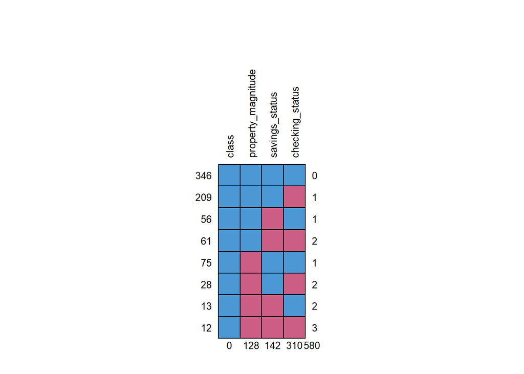

```
##     class property_magnitude savings_status checking_status
## 346     1                  1              1               1   0
## 209     1                  1              1               0   1
## 56      1                  1              0               1   1
## 61      1                  1              0               0   2
## 75      1                  0              1               1   1
## 28      1                  0              1               0   2
## 13      1                  0              0               1   2
## 12      1                  0              0               0   3
##         0                128            142             310 580
```

```r
par(cex = 0.8)
train %>% select(class,checking_status,savings_status,property_magnitude) %>% md.pattern(plot=TRUE,rotate.names=TRUE)
```

## 문제 11

```
checking_status 와 savings_status는 범주형 변수로 처리하는 것이 맞음. 근데 문제 7에서 순서형 자료로 1,2,3.. 을 부여하고 이후 문제 8에서 int를 num으로 chr를 factor로 변경하는 과정에서 numeric으로 처리되었음. 그 때문에 연속형변수로 다뤄져서 missing_pairs() 그래프에서 두 변수에 대한 부분이 이상하게 나타나짐.
```

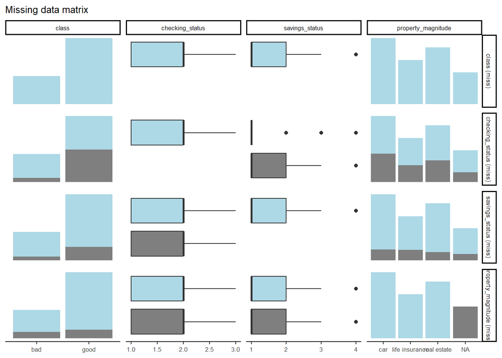

```
checking_status, savings_status를 factor로 처리하고 그래프를 다시 그렸음. 지금은 각 변수끼리의 결측치 발생 빈도만을 시각화 하고자하는 것임으로 순서형 자료를 factor로 전환문제가 없음.
```

```r
train %>% select(class,checking_status,savings_status,property_magnitude) %>% missing_pairs() %>%  + theme(
  text = element_text(size = 8)  # 글자 크기 조절
)
```

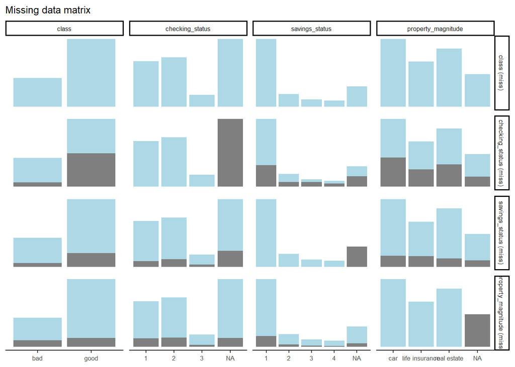

```r
z<-train
z$checking_status<-as.factor(train$checking_status)
z$savings_status<-as.factor(train$savings_status)
z %>% select(class,checking_status,savings_status,property_magnitude) %>% missing_pairs() %>%  + theme(
  text = element_text(size = 8))
```

### missing data matrix 해석

- class 일 경우
  - checking_status의 결측치가 good 부분에 상당히 많은 것을 알 수 있음.
- checking_status 일 경우
  - savings_status, property_magnitude의 결측치가 범주 별로 고르게 분포함을 알 수 있음.
- saving_status 일 경우
  - checking status의 결측치가 범주 1에 좀 많이 분포하고 있는 것이 확인됨 .
  - savings_status의 NA 중 50퍼센트 정도가 checking stauts와 같은 열에서 발생함을 확인할 수 있음.
- property_magnitude 일 경우
  - savings_status의 결측치는 각 범주 별 고르게 분포함.
  - checking_status의 결측치도 나름 고르게 분포함.
  - savings_status가 결측치 일 때, checking_status의 결측치의 비율이 약 50퍼센트 였던 것에 비해 그 반대는 비율이 상대적으로 낮음.

## 문제 12

### 전처리 전 갯수 확인

```r
# 결측치 처리 전 갯수 확인
train$property_magnitude %>% is.na() %>% sum() %>%
  cat("missing property magnitude before : ", .,end="\n")
```

```
## missing property magnitude before :  128
```

```r
train$checking_status %>% is.na() %>% sum() %>%
  cat("missing checking status before : ", .,end="\n")
```

```
## missing checking status before :  310
```

```r
train$savings_status %>% is.na() %>% sum() %>%
  cat("missing savings status before : ", .)
```

```
## missing savings status before :  142
```

```r
train %>% select(checking_status,savings_status) %>% table()
```

```
##                savings_status
## checking_status   1   2   3   4
##               1 161  10   7   5
##               2 129  42   8  13
##               3  36   4   3   3
```

```r
# mode 함수 정의
getmode <- function(x) {
  ux <- unique(x)
  ux[which.max(tabulate(match(x, ux)))]
}

mode_value <- getmode(train$property_magnitude)

# 결측치 대체
train <- train %>% mutate(
  property_magnitude = ifelse(property_magnitude %>% is.na(),mode_value,property_magnitude),
  checking_status = case_when(
    ((checking_status %>% is.na) & (savings_status == 1)) ~ 1,
    ((checking_status %>% is.na) & (savings_status == 2)) ~ 2,
    ((checking_status %>% is.na) & (savings_status == 3)) ~ 2,
    ((checking_status %>% is.na) & (savings_status == 4)) ~ 2,
    ((checking_status %>% is.na) & (savings_status %>% is.na)) ~ 1,
    TRUE ~ checking_status
  ),
  savings_status = ifelse(savings_status %>% is.na(),1,savings_status))

# test에도 동일하게 처리
test <- test %>% mutate(
  property_magnitude = ifelse(property_magnitude %>% is.na(),mode_value,property_magnitude),
  checking_status = case_when(
    ((checking_status %>% is.na) & (savings_status == 1)) ~ 1,
    ((checking_status %>% is.na) & (savings_status == 2)) ~ 2,
    ((checking_status %>% is.na) & (savings_status == 3)) ~ 2,
    ((checking_status %>% is.na) & (savings_status == 4)) ~ 2,
    ((checking_status %>% is.na) & (savings_status %>% is.na)) ~ 1,
    TRUE ~ checking_status
  ),
  savings_status = ifelse(savings_status %>% is.na(),1,savings_status))
```

### 전처리 후 갯수 확인

```r
# 결측치 처리 후 갯수 확인
train$property_magnitude %>% is.na() %>% sum() %>%
  cat("missing property magnitude after : ", .,end="\n")
```

```
## missing property magnitude after :  0
```

```r
train$checking_status %>% is.na() %>% sum() %>%
  cat("missing checking status after : ", .,end="\n")
```

```
## missing checking status after :  0
```

```r
train$savings_status %>% is.na() %>% sum() %>%
  cat("missing savings status after : ", .)
```

```
## missing savings status after :  0
```

# Chapter 2 : EDA

## 문제 1

### 각각의 변수에 대해 그래프 만들고 저장하기

```r
color3 <- c("#00AFBB", "#E7B800", "#999999")
skyblue <-"#00AFBB"
num_list <-c("duration","credit_amount","age")
graph_list <-c()

for (names in colnames(train)){
  if (names %in% num_list){
    x <- ggplot(train,aes(x=.data[[names]],y=..density..))+
      geom_histogram(color='black',fill=skyblue,alpha=0.5)+
      geom_density(fill=skyblue,alpha=0.2,color=skyblue)+
      labs(x=names,fill=names)+
      theme_classic()+
      theme(text = element_text(size=5))
    graph_list<-c(graph_list,list(x))

  }

  else if(length(unique(train[[names]]))>3){
    z <- ggplot(train)+geom_bar(aes(x=.data[[names]],
                                    fill=factor(.data[[names]])),
                                color='black'
                                )+
      scale_fill_brewer(palette="Set3")+
      labs(x=names,fill=names)+
      theme(text=element_text(size=1))+
      theme_classic()+
      theme(legend.key.size = unit(0.2,'cm'),
            text = element_text(size=5))
    graph_list<-c(graph_list,list(z))
  }
  else if (length(unique(train[[names]])<=3)){
    y <- ggplot(train)+geom_bar(aes(x=.data[[names]],fill=factor(.data[[names]])),
                                color='black'
                                )+
      scale_fill_manual(values=color3)+
      labs(x=names,fill=names)+
      theme_classic()+
      theme(legend.key.size = unit(0.2,'cm'),
            text = element_text(size=5))
    graph_list<-c(graph_list,list(y))
  }
}
```

### grid.arrange로 그래프 합치기

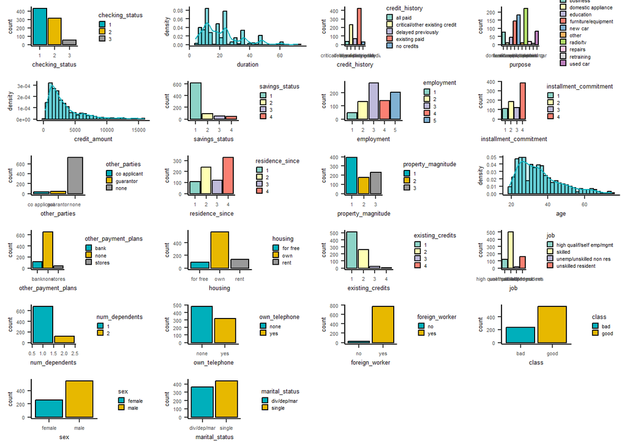

```r
grid.arrange(grobs=graph_list[1:22] , ncol=4,nrow=6)
```

## 문제 보너스 3

### 각각의 변수에 대해 class별 그래프 만들고 저장하기

```r
color3 <- c("#00AFBB", "#E7B800", "#999999")
skyblue <-"#00AFBB"
num_list <-c("duration","credit_amount","age")
graph_list <-c()

for (names in colnames(train)){
  if (names %in% num_list){
    x <- ggplot(train,aes(x=.data[[names]],y=..density..,fill=class))+
      geom_histogram(color='black',alpha=0.5,position = 'dodge')+
      geom_density(alpha=0.2,color='black')+
      labs(x=names,fill=names)+
      theme_classic()+
      theme(legend.key.size = unit(0.2,'cm'),
            text = element_text(size=7))
    graph_list<-c(graph_list,list(x))

  }

  else if(length(unique(train[[names]]))>3){
    z <- ggplot(train)+geom_bar(aes(x=class,fill=factor(.data[[names]])),
                                color='black',
                                position='dodge'
                                )+
      scale_fill_brewer(palette="Set1")+
      labs(x=names,fill=names)+
      theme(text=element_text(size=1))+
      theme_classic()+
      theme(legend.key.size = unit(0.2,'cm'),
            text = element_text(size=7))
    graph_list<-c(graph_list,list(z))
  }
  else if (length(unique(train[[names]])<=3)){
    y <- ggplot(train)+geom_bar(aes(x=class,fill=factor(.data[[names]])),
                                color='black',
                                position='dodge'
                                )+
      scale_fill_manual(values=color3)+
      labs(x=names,fill=names)+
      theme_classic()+
      theme(legend.key.size = unit(0.2,'cm'),
            text = element_text(size=7))
    graph_list<-c(graph_list,list(y))
  }
}
```

### grid.arrange로 그래프 합치기

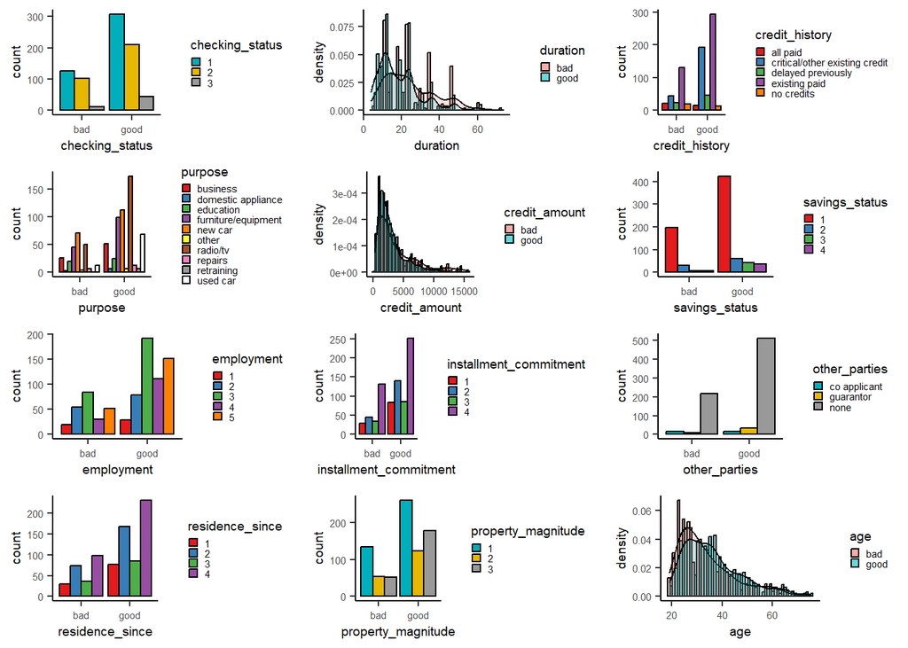

```r
grid.arrange(grobs=graph_list[1:12] , ncol=3,nrow=4)
```

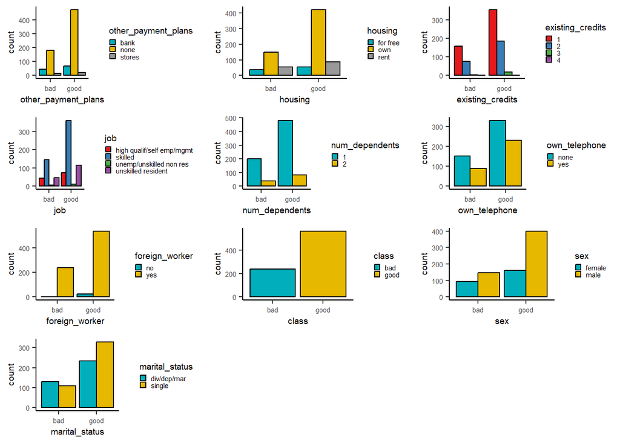

```r
grid.arrange(grobs=graph_list[13:22] , ncol=3,nrow=4)
```

```r
train %>% filter(class=='good') %>% dim()
```

```
## [1] 561  22
```

```r
train %>% filter(class=='bad') %>% dim()
```

```
## [1] 239  22
```

# Chapter 3 모델링

## 문제 1

```
위에서 불러옴
```

## 문제 2

1. ntree: 의사결정 나무의 개수로 기본값은 500임. ntree가 높을수록 모델 복잡도가 증가하여 정확도가 향상될 수 있지만, 과대적합의 위험이 증가함.
2. mtry: 각 의사결정 나무에서 분할할 때 랜덤하게 선택되는 변수의 개수로 기본값은 sqrt(p)임. mtry가 높을수록 모델의 복잡도가 증가하여 정확도가 향상될 수 있지만, 과대적합의 위험도 증가함.
3. maxdepth: 각 의사결정 나무의 최대 깊이로 기본값은 5임. maxdepth가 높을수록 모델의 복잡도가 증가하여 정확도가 향상될 수 있지만, 과대적합의 위험도 증가함.
4. nodesize: 각 의사결정 나무의 리프 노드에 포함되어야 하는 최소 데이터 수로 기본값은 5임. nodesize가 작을수록 모델의 복잡도가 증가하여 정확도가 향상될 수 있지만, 과대적합의 위험도 증가함.
5. minsplit: 각 의사결정 나무에서 분할을 수행하기 위한 최소 데이터 수입니다. 기본값은 2임. minsplit이 작을수록 모델의 복잡도가 증가하여 정확도가 향상될 수 있지만, 과대적합의 위험도 증가함.
6. replace: 각 의사결정 나무에서 데이터를 샘플링할 때 샘플을 대체할지 여부로 기본값은 TRUE입니다. replace가 TRUE이면 각 데이터가 여러 번 샘플링될 수 있음. 이는 과대적합의 위험을 줄이는 데 도움이 될 수 있음.
7. importance: 변수 중요도를 계산할지 여부로 기본값은 FALSE임. importance가 TRUE이면 각 변수가 모델의 예측에 얼마나 중요한지 계산함.

## 문제 3

```r
x_train<-train %>% select(-class)
rf_model<-randomForest(x=x_train,y=train$class,ntree=100,importance = TRUE)
```

### 변수 중요도 출력

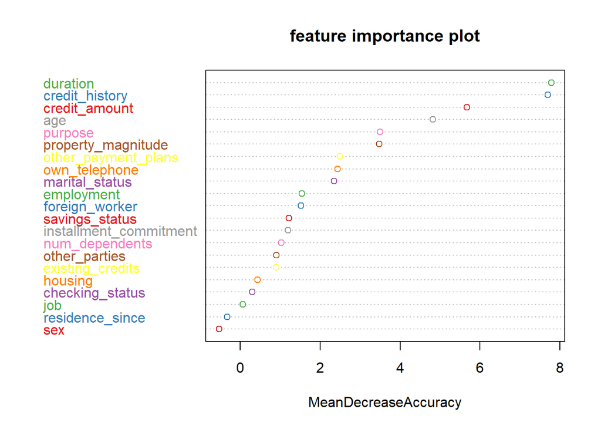

```r
impcolor <- brewer.pal(22,"Set1")
varImpPlot(rf_model,main="feature importance plot",col=impcolor,
           type=1)
```

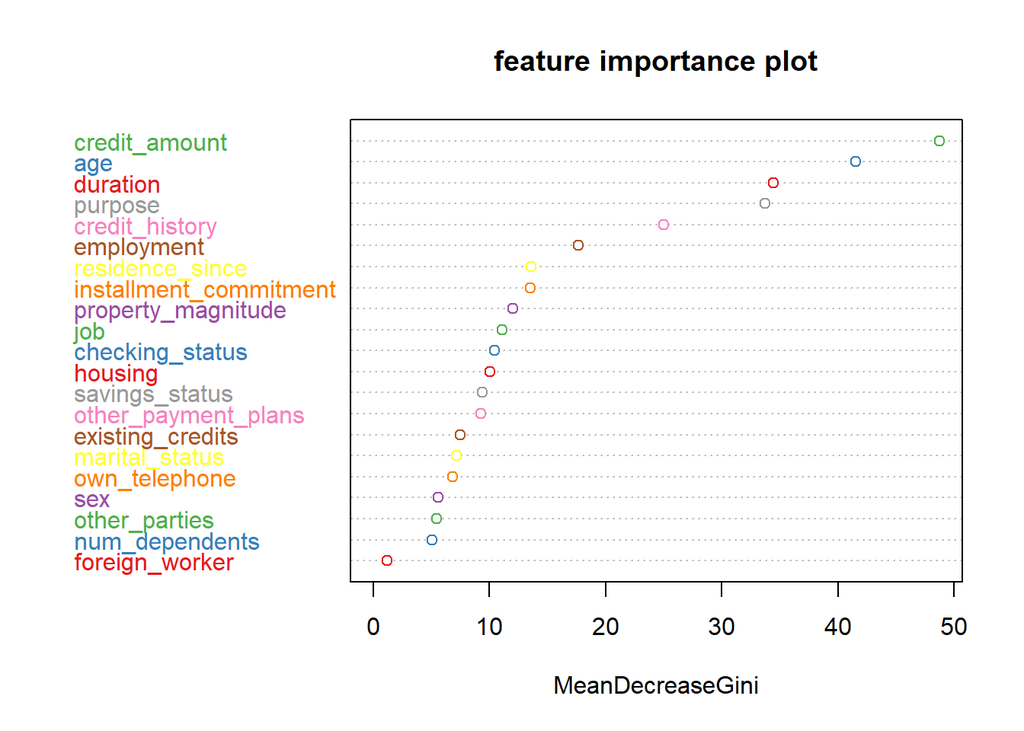

```r
varImpPlot(rf_model,main="feature importance plot",col=impcolor,
           type=2)
```

### 대출 승인에 영향을 미치는 변수

- varimpplot은 2가지를 기준으로 변수중요도를 제시한다.
  1. MeanDecreaseAccuracy
  2. MeanDecreaseGini
- 그래프를 기준으로 변수 중요도가 크게 꺽이는 지점인 5번째 변수까지 2가지 기준에 대해 확인해보면 아래와 같다.

[output not shown]

```
## [1] "credit_amount"  "age"            "duration"       "purpose"
## [5] "credit_history"
```

```
## [1] "----------------------------------------------------------------------"
```

[output not shown]

```
## [1] "duration"       "credit_history" "credit_amount"  "age"
## [5] "purpose"
```

## 문제 4

```r
lg_model <- glm(class~.,data=train,family="binomial")
summary(lg_model)
```

```
##
## Call:
## glm(formula = class ~ ., family = "binomial", data = train)
##
## Deviance Residuals:
##     Min       1Q   Median       3Q      Max
## -2.4978  -0.8827   0.4513   0.7573   2.9745
##
## Coefficients:
##                                                Estimate Std. Error z value
## (Intercept)                                   4.151e-01  1.363e+00   0.305
## checking_status                              -1.275e-01  1.500e-01  -0.850
## duration                                     -2.760e-02  9.793e-03  -2.818
## credit_historycritical/other existing credit  2.037e+00  4.780e-01   4.262
## credit_historydelayed previously              1.345e+00  5.049e-01   2.664
## credit_historyexisting paid                   1.153e+00  4.224e-01   2.730
## credit_historyno credits                      1.298e-01  5.868e-01   0.221
## purposedomestic appliance                    -3.773e-01  8.836e-01  -0.427
## purposeeducation                             -9.266e-01  4.629e-01  -2.002
## purposefurniture/equipment                   -2.414e-01  3.714e-01  -0.650
## purposenew car                               -8.687e-01  3.574e-01  -2.431
## purposeother                                  2.994e-01  8.572e-01   0.349
## purposeradio/tv                               1.841e-01  3.551e-01   0.519
## purposerepairs                               -5.263e-01  6.111e-01  -0.861
## purposeretraining                             1.655e+00  1.182e+00   1.400
## purposeused car                               1.048e+00  4.754e-01   2.204
## credit_amount                                -1.022e-04  4.787e-05  -2.135
## savings_status                                3.949e-01  1.349e-01   2.928
## employment                                    2.013e-01  8.566e-02   2.350
## installment_commitment                       -3.321e-01  9.260e-02  -3.586
## other_partiesguarantor                        1.521e+00  6.328e-01   2.403
## other_partiesnone                             9.145e-01  4.476e-01   2.043
## residence_since                              -2.771e-02  9.070e-02  -0.306
## property_magnitude                            1.254e-01  1.182e-01   1.061
## age                                           1.430e-02  9.703e-03   1.473
## other_payment_plansnone                       2.738e-01  2.565e-01   1.067
## other_payment_plansstores                    -1.488e-01  4.364e-01  -0.341
## housingown                                    4.078e-01  3.224e-01   1.265
## housingrent                                  -3.192e-03  3.782e-01  -0.008
## existing_credits                             -3.088e-01  1.981e-01  -1.559
```

[output cut: 42 more lines]

```
## num_dependents                               0.033020 *
## own_telephoneyes                             0.040689 *
## foreign_workeryes                            0.059717 .
## sexmale                                      0.148212
## marital_statussingle                         9.32e-05 ***
## ---
## Signif. codes:  0 '***' 0.001 '**' 0.01 '*' 0.05 '.' 0.1 ' ' 1
##
## (Dispersion parameter for binomial family taken to be 1)
##
##     Null deviance: 975.68  on 799  degrees of freedom
## Residual deviance: 781.38  on 762  degrees of freedom
## AIC: 857.38
##
## Number of Fisher Scoring iterations: 5
```

[output not shown]

```r
j=0
n_list <-c()
coefficients <- lg_model %>% coef()
coefficient_matrix <- summary(lg_model)$coefficients
for (i in names(sort(coefficients,decreasing = T))){
  j = j+1
  if (abs(coefficient_matrix[,4][[i]])<=0.05){
    n_list <-c(n_list,i)
  }
  if (j==15){
    break
  }
}
```

```
x변수가 총 21개여서 feature importance에서 5번째에서 짜른 것과 비교해 봤을 때 15개가 너무 많아보일 수 있는데 그렇게 고려한 이유는 (애초에 주관적이긴하지만) 사진에서 purpose부분을 보면 알 수 있듯이 각 변수의 범주별로 계수가 추정되기 때문에 실제로는 21개가 아니기 때문이다.
```

## 문제5

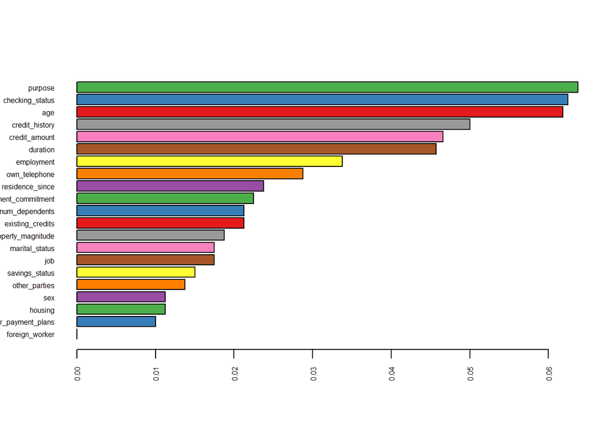

```r
cr_model <- CoreModel(class~., train)
sorted_fi<-sort(attrEval(class~., train, estimator="Relief"))
barplot(sorted_fi,col=impcolor,horiz=T,las=2,cex.names=0.5,cex.axis = 0.5)
```

## 문제 보너스 4

- Relief 알고리즘은 변수 선택에 사용할 수 있는 알고리즘. Relief 알고리즘은 각 특성의 값을 무작위로 수정하고 이를 이용하여최종적으로그특성이 클래스 분류에 얼마나 중요한지를 측정함.
- Relief 알고리즘은 다음과 같은 단계로 수행됨.
  1. 훈련 데이터 세트에서 데이터 포인트 하나를 선택.
  2. 선택한 데이터 포인트의 클래스를 찾음.
  3. 선택한 데이터 포인트의 각 특성의 값을 무작위로 수정.
  4. 수정된 데이터 포인트를 사용하여 클래스 레이블을 예측.
  5. 예측된 클래스 레이블과 실제 클래스 레이블이 일치하지 않으면해당 특성의 중요도를 증가시킴.
  6. 모든 데이터 포인트에 대해 위의 단계를 반복함.
  7. 각 특성의 중요도를 합산하여 특성 중요도 점수를 계산.
- Relief 알고리즘은 다음과 같은 장점이 있음.
  1. 특성의 중요도를 상대적으로 평가할 수 있음.
  2. 특성의 스케일에 영향을 받지 않음.
  3. 다중 클래스 분류에 적용할 수 있음.
- Relief 알고리즘은 다음과 같은 단점이 있음.
  1. 시간이 오래 걸릴 수 있음.
  2. 이상치에 민감할 수 있음.

## 문제 6

```r
x_train <- train %>% select(credit_amount, duration, purpose, credit_history,checking_status, savings_status,age,marital_status)
x_test <- test %>% select(credit_amount, duration, purpose, credit_history,checking_status, savings_status,age,marital_status)

final_model<-randomForest(x=x_train,y=train$class)
pred<-predict(final_model,x_test)
confusionMatrix(pred,test$class,mode='everything')
```

```
## Confusion Matrix and Statistics
##
##           Reference
## Prediction bad good
##       bad   16   17
##       good  45  122
##
##                Accuracy : 0.69
##                  95% CI : (0.6209, 0.7533)
##     No Information Rate : 0.695
##     P-Value [Acc > NIR] : 0.5947351
##
##                   Kappa : 0.1607
##
##  Mcnemar's Test P-Value : 0.0006058
##
##             Sensitivity : 0.2623
##             Specificity : 0.8777
##          Pos Pred Value : 0.4848
##          Neg Pred Value : 0.7305
##               Precision : 0.4848
##                  Recall : 0.2623
##                      F1 : 0.3404
##              Prevalence : 0.3050
##          Detection Rate : 0.0800
##    Detection Prevalence : 0.1650
##       Balanced Accuracy : 0.5700
##
##        'Positive' Class : bad
##
```

```r
x_train <- train %>% select(-class)
x_test<-test %>% select(-class)
final_model<-randomForest(x=x_train,y=train$class)
pred<-predict(final_model,x_test)
confusionMatrix(pred,test$class,mode='everything')
```

```
## Confusion Matrix and Statistics
##
##           Reference
## Prediction bad good
##       bad   15   12
##       good  46  127
##
##                Accuracy : 0.71
##                  95% CI : (0.6418, 0.7718)
##     No Information Rate : 0.695
##     P-Value [Acc > NIR] : 0.3537
##
##                   Kappa : 0.1892
##
##  Mcnemar's Test P-Value : 1.47e-05
##
##             Sensitivity : 0.2459
##             Specificity : 0.9137
##          Pos Pred Value : 0.5556
##          Neg Pred Value : 0.7341
##               Precision : 0.5556
##                  Recall : 0.2459
##                      F1 : 0.3409
##              Prevalence : 0.3050
##          Detection Rate : 0.0750
##    Detection Prevalence : 0.1350
##       Balanced Accuracy : 0.5798
##
##        'Positive' Class : bad
##
```

- F1 score가 0.3 언저리로 처참한 성능을 보이고 있다. full model이 변수 선택을 한 모델 보다 성능이좋다.
- 그러나 일단 기본적인 성능이 너무 낮아서, 변수를 추가로 수집하든가 아니면 데이터를 더 확보하던가, 변수 변환을 하던가, 파생변수를 하던가 등의 방법이 필요해보인다.
- (추신) R에서 lgb,xgb 쓸라니까 진짜 복잡했는데 꾸역꾸역해서 되긴됐음. 근데 rf보다 성능이 더 않좋았음. 모든 class를 good으로 예측함.